# R interface to keras 설치 안내 사항

## 1.R 및 R studio 설치 안내

- R 다운로드 후 기본 설정으로 설치  
  [Window 64 bit R 설치파일 링크](https://cran.r-project.org/bin/windows/base/old/3.6.3)  
  OS가 다르거나 64비트가 아닌경우 아카이브에서 알맞은 버전 확인 후 설치  
  [R 아카이브](https://cran.r-project.org/bin/)
- R studio 다운로드 후 기본 설정으로 설치  
  [Window 64 bit R studio 설치파일 링크](https://download1.rstudio.org/desktop/windows/RStudio-1.3.1056.exe)

## 2.Anaconda 설치

- Anaconda 아카이브에서 Anaconda3-5.2.0-Windows-x86_64.exe 파일을 다운로드 후 설치  
  [Window 64 bit Anaconda 설치파일 링크](https://repo.anaconda.com/archive/Anaconda3-5.2.0-Windows-x86_64.exe)
- OS가 다르거나 64비트가 아닌경우 아카이브에서 알맞은 버전 확인 후 설치  
  [Anaconda 아카이브 링크](https://repo.anaconda.com/archive)
- 설치 과정 :

[figure not shown]

## 2-1 CUDA Tookit 및 Cudnn 설치 (GPU버전 설치자만 해당)

- 본인의 그래픽 카드를 확인(window 10 기준)  
  윈도우메뉴 우클릭-> 장치 관리자 -> 디스플레이 어댑터 -> 그래픽카드 명칭 확인

[figure not shown]

- 그래픽카드에 알맞은 최신 드라이버 설치  
  [그래픽카드 최신드라이버 설치](https://www.nvidia.com/Download/index.aspx?lang=kr)

[figure not shown]

- 그래픽카드의 Compute capability(verison)을 확인하고 알맞은 Cuda toolkit version 찾기  
  [CUDA Tookit 버전 확인](https://en.wikipedia.org/wiki/CUDA#Version_features_and_specifications)

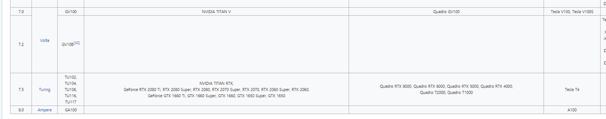

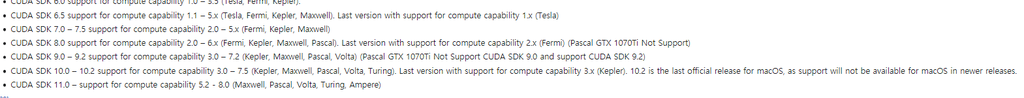

- 확인한 CUDA Toolkit 버전 설치 [CUDA Tookit 아카이브](https://developer.nvidia.com/cuda-toolkit-archive)

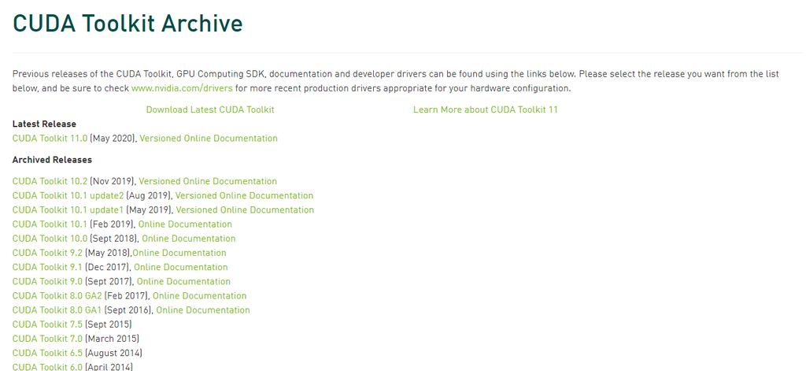

- CUDA Toolkit 버전에 알맞은 cuDNN 버전 설치 다운로드 받기위해 nvidia회원가입이 필요함  
  [cuDNN 다운로드](https://developer.nvidia.com/rdp/cudnn-download)

[figure not shown]

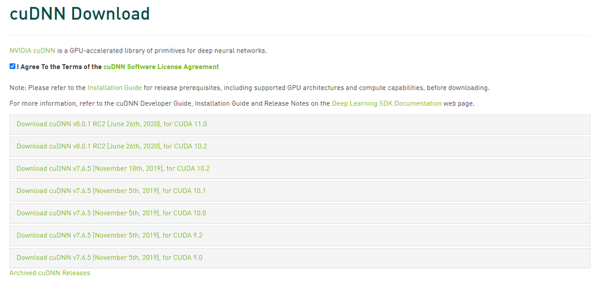

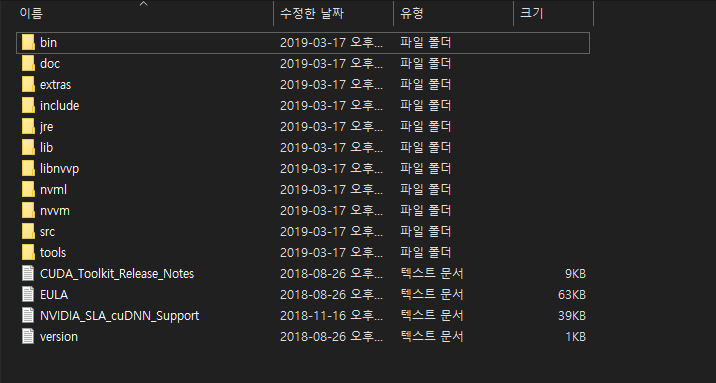

## 3.Anaconda prompt 실행

- 가상환경 생성
  - CPU ver 설치시  
    `conda create --p C:\ProgramData\Anaconda3\envs\r-tensorflow python==3.6.5 tensorflow==2.0.0 keras==2.3.1 pillow==6.0.0`
  - GPU ver 설치시  
    `conda create --p C:\ProgramData\Anaconda3\envs\r-tensorflow python==3.6.5 tensorflow-gpu==2.0.0 keras==2.3.1 pillow==6.0.0`
- 생성 된 가상 환경 확인 `conda info --envs`
- 가상환경 활성화 `activate r-tensorflow`
- 파이썬 실행 `python`
- python에서 tensorflow 및 keras가 설치 되었는지 확인

```python
import tensorflow as tf
import keras
tf.__version__
keras.__version__
#버전명이 출력되면 정상 설치 완료
```

## 4.R studio 실행 및 R studio 상에서 아래의 커맨드를 순차적으로 입력

```r
library(reticulate)
use_python('C:/ProgramData/Anaconda3/envs/r-tensorflow/python.exe')
use_virtualenv('C:/ProgramData/Anaconda3/envs/r-tensorflow')
use_condaenv('r-tensorflow')
install.packages("keras")
library(keras)
```

## 5.자주 발생하는 설치 실패 원인.

- 아나콘다 시스템 환경 변수설정에 문제가 있는 경우 아래의 경로가 시스템 환경변수 PATH 안에 있어야함.  
  `C:\ProgramData\Anaconda3` `C:\ProgramData\Anaconda3\Library\mingw-w64\bin` `C:\ProgramData\Anaconda3\Library\usr\bin` `C:\ProgramData\Anaconda3\Library\bin` `C:\ProgramData\Anaconda3\Scripts`
- GPU 버전의 경우 CUDA Toolkit 버전이 Tensorflow에서 지원하지 않는 경우, cuDNN 복사를 잘못한 경우, 시스템 환경변수에 CUDA 관련 path 가 잡히지 않은경우 3가지 정도로 원인을 생각해 볼수 있습니다. GPU 버전은 사용자 개별 pc 환경이나 설치 시기가 영향을 미쳐 설치할 때 마다 버전 조합을 찾는 시행착오를 겪으실 수 있습니다.
- 디스크 용량이 부족한 경우에 가상환경이 생성되지 않는 경우가 있음.
- 앞에서 지정한 경로 `C:\ProgramData\Anaconda3` 아나콘다를 설치하지 않고 다른 경로에 설치하는 경우는 위 안내사항에서 모든 경로를 해당 경로로 맞추어 주셔야 합니다.
- 관리자 권한 설치 필요한 경우 R, Anaconda를 모두 관리자 권한으로 설치 + Anaconda Prompt 관리자 권한으로 실행
- 개별 사용 보안 프로그램 및 백신 (일시적 사용 중지 권장)
- 네트워크 환경 열악 ( 패키지 다운로드에 많은 시간이 걸리다 연결이 중단 되는 경우 실패 )
- 한 컴퓨터 내에서 윈도우 계정을 여러개 사용하는 경우 특정 사용자에게만 환경 변수가 추가되어있는 경우가 있음.
- 설치가 꼬인 경우 Anaconda prompt에 `conda env remove --name=r-tensorflow` 를 입력하여 가상환경을 지우고 nvidia 관련 프로그램 또한 윈도우 프로그램 추가 제거에서 모두 지우고 다시 설치 시돌르 해보기를 추천합니다.